# **Student performance including alcohol consumption**

### **3. Numerically and graphically exploring the distributions of chosen variables and their relationships with alcohol consumption.**

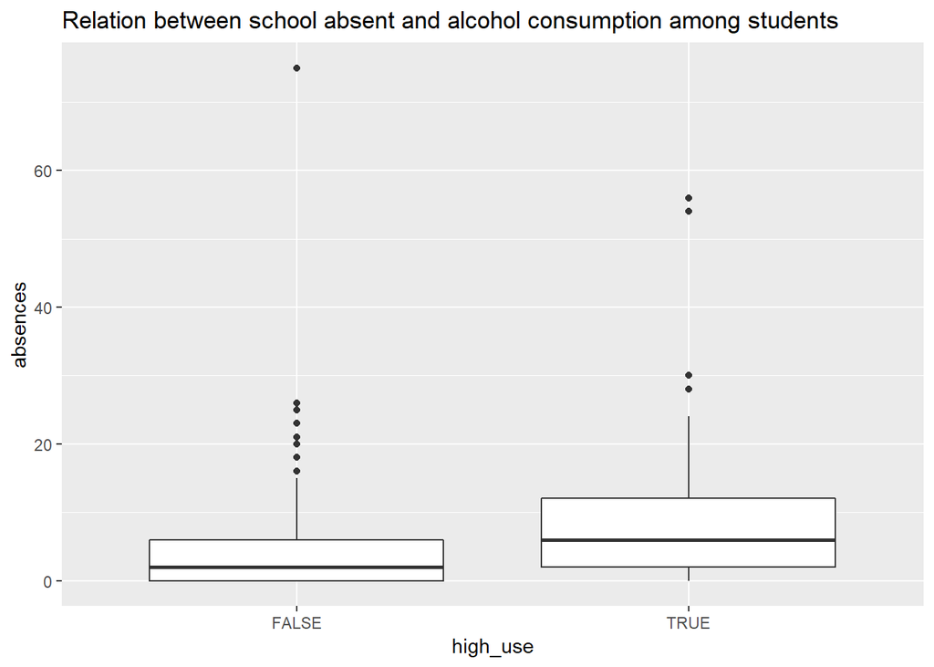

- Similar to my above mentioned hypothesis,the students who had more absences tended to consume more alcohol.

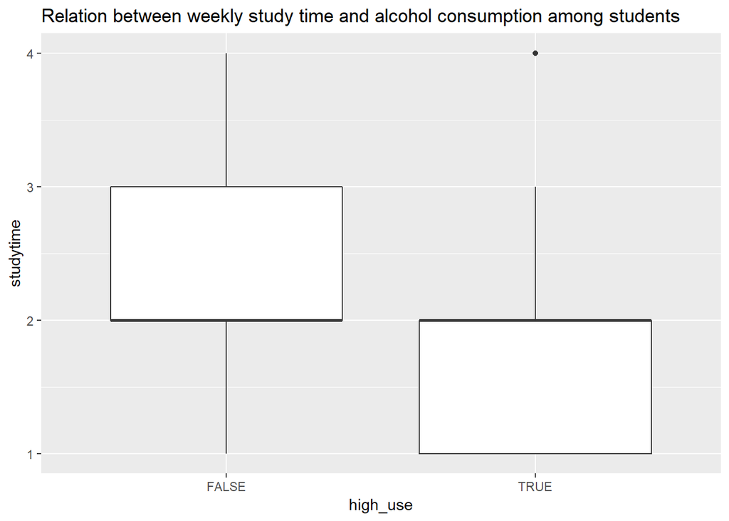

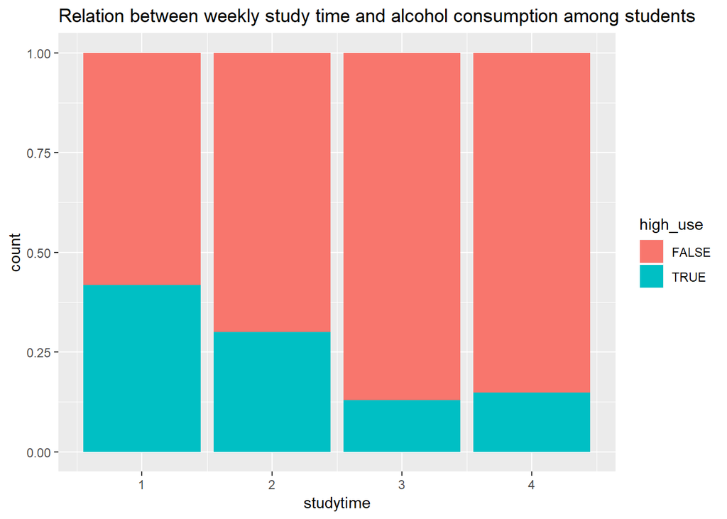

```
## # A tibble: 8 x 3
## # Groups:   studytime [?]
##   studytime high_use count
##       <int> <lgl>    <int>
## 1         1 FALSE       60
## 2         1 TRUE        43
## 3         2 FALSE      133
## 4         2 TRUE        57
## 5         3 FALSE       54
## 6         3 TRUE         8
## 7         4 FALSE       23
## 8         4 TRUE         4
```

- The students who has spent less time on studies tended to have more alcohol consumption is in afreement with my hypothesis.

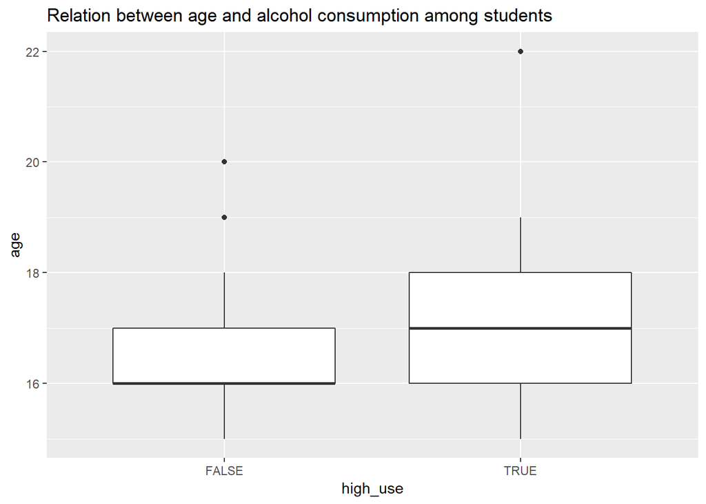

```
## # A tibble: 12 x 3
## # Groups:   age [?]
##      age high_use count
##    <int> <lgl>    <int>
##  1    15 FALSE       63
##  2    15 TRUE        18
##  3    16 FALSE       79
##  4    16 TRUE        28
##  5    17 FALSE       65
##  6    17 TRUE        35
##  7    18 FALSE       55
##  8    18 TRUE        26
##  9    19 FALSE        7
## 10    19 TRUE         4
## 11    20 FALSE        1
## 12    22 TRUE         1
```

- Students with more age tended to have more alcohol consumption. This is in line with my hypothesis.

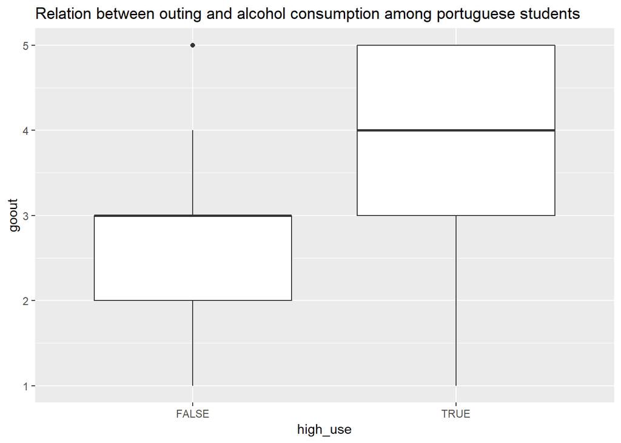

```
## # A tibble: 10 x 3
## # Groups:   goout [?]
##    goout high_use count
##    <int> <lgl>    <int>
##  1     1 FALSE       21
##  2     1 TRUE         3
##  3     2 FALSE       84
##  4     2 TRUE        15
##  5     3 FALSE      100
##  6     3 TRUE        23
##  7     4 FALSE       43
##  8     4 TRUE        39
##  9     5 FALSE       22
## 10     5 TRUE        32
```

- Students who had frequent outings tended to have more alcohol consumption and in line with my hypothesis.